# Decision Making for Management

Session 2: Report clinic and tests for one and two groups

Mohammed Ali Sharafuddin

## Session 2 activities

Discussion

**1 Report clinic**

⏱ 30 min

How the report is marked, a checklist, common errors, and RBV and VRIO

Acquisition

**2 Choosing a test and the one-sample t-test**

⏱ 35 min

Design first, then variable type, then the one-sample t-test in JASP

Practice

**3 Rank-based tests**

⏱ 40 min

The Wilcoxon signed-rank and Mann-Whitney U tests, with your-turn tasks

Investigation

**4 Paired samples t-test**

⏱ 25 min

Before-and-after data, run and reported in JASP

Assessment

**5 Choosing correctly and recap**

⏱ 30 min

The tests side by side, scenarios, common mistakes and the selection rules

## Session 2

**Today’s focus**

- **Report clinic:** how the coursework is marked, and the common errors
- **One-sample t-test** and **Wilcoxon signed-rank test**
- **Mann-Whitney U test** and **paired samples t-test**
- The core decision: choose the test that matches the **design** and the **variable type**

## Today’s session

| Time | Topic |
| --- | --- |
| 0:00 | Report clinic, including RBV and VRIO |
| 0:30 | Choosing a test, then the one-sample t-test |
| 1:05 | Break |
| 1:15 | Wilcoxon signed-rank and Mann-Whitney U |
| 1:55 | Break |
| 2:05 | Paired samples t-test |
| 2:30 | Choosing correctly, and recap |

## How the report is marked

| Criterion | Marks | What earns the marks |
| --- | --- | --- |
| Dataset and task | 10 | Coursework file, exact names, all sections |
| A: the sample | 15 | Frequencies, means, SDs, normality from three checks |
| B: two groups | 20 | Levene’s test, correct row, t, df, p, means, d, meaning |
| C: relationship | 20 | r, p, R², labelled scatterplot, causation caution |
| D: recommendation | 20 | Built on A to C, one framework used analytically |
| Writing and appendices | 15 | Report style, appendices, references, AI note |

## Checklist before submission

- Only `DMM_Coursework_Data.csv` is used
- Variable names match the brief exactly
- Sections A to D, an executive summary and a conclusion are present
- Each JASP output sits in a **labelled appendix** and is referred to in the text
- The scatterplot has a figure number, a title and axis labels
- The AI declaration appendix is included
- One PDF is uploaded

## Common errors, section by section

- **A:** normality judged from Shapiro-Wilk alone
- **B:** the wrong row reported, or no Cohen’s d
- **C:** R² missing, or a causal claim made from a correlation
- **D:** a recommendation that never names the evidence from A to C
- **All:** JASP output pasted with no sentence explaining it

## RBV and VRIO: the alternative framework for Section D

[figure not shown]

## VRIO Classifier

[interactive chart not shown]

[Open the VRIO Classifier in a new tab](https://flairmi.com/toolkit/vrio-classifier.html)

## Section D through VRIO: an example

**Evidence, framework, action**

In the teaching file, 57.5% of customers rate their intention to return at 4 or 5. **Through the VRIO framework**, this loyal customer base is valuable and hard for a new organiser to copy, but the firm is not yet organised to use it. **We recommend** a returning-customer programme, with repeat bookings monitored over the next three events.

## Learning outcomes for the tests

By the end of the session, you should be able to:

- distinguish **one group**, **independent groups** and **paired data**
- choose between a **mean-based** and a **rank-based** test
- run each of the four tests in JASP and read the output
- report each result with its key statistics and a plain-language conclusion

## Choosing a test: start with the design

**Start with this question**

Are you comparing:

1. **one group** with a fixed benchmark,
2. **two different groups**, or
3. **the same cases twice**?

## One group, two groups, or the same cases twice

### One group

- one sample against a target
- example: mean spending against the budget

### Two groups

- different people in each group
- example: day shift against night shift

### Matched pairs

- the same people measured twice
- example: before and after training

## The second choice is variable type

### Scale outcome

- the focus is on **means**
- leads to a **t-test**

### Ordinal or ranked outcome

- the focus is on **ranks**
- leads to a **rank-based test**

## Decision map

- **One group + scale** → **One-sample t-test**
- **One group + ordinal** → **Wilcoxon signed-rank test**
- **Two independent groups + ordinal** → **Mann-Whitney U test**
- **Same cases twice + scale** → **Paired samples t-test**

The independent samples t-test, for two groups and a scale outcome, was covered in session 1.

## One-sample t-test

**Main question**

Does the **mean** of one group differ from a fixed **benchmark**?

- **H₀:** the population mean equals the benchmark
- **H₁:** the population mean differs from the benchmark

## Example: spending against the plan

**The marketing plan**

The plan assumed each customer would spend **450 USD**. In the teaching file, the 200 customers spent **505.65 USD** on average. Is the difference larger than sampling variation would produce?

## One-sample t-test in JASP

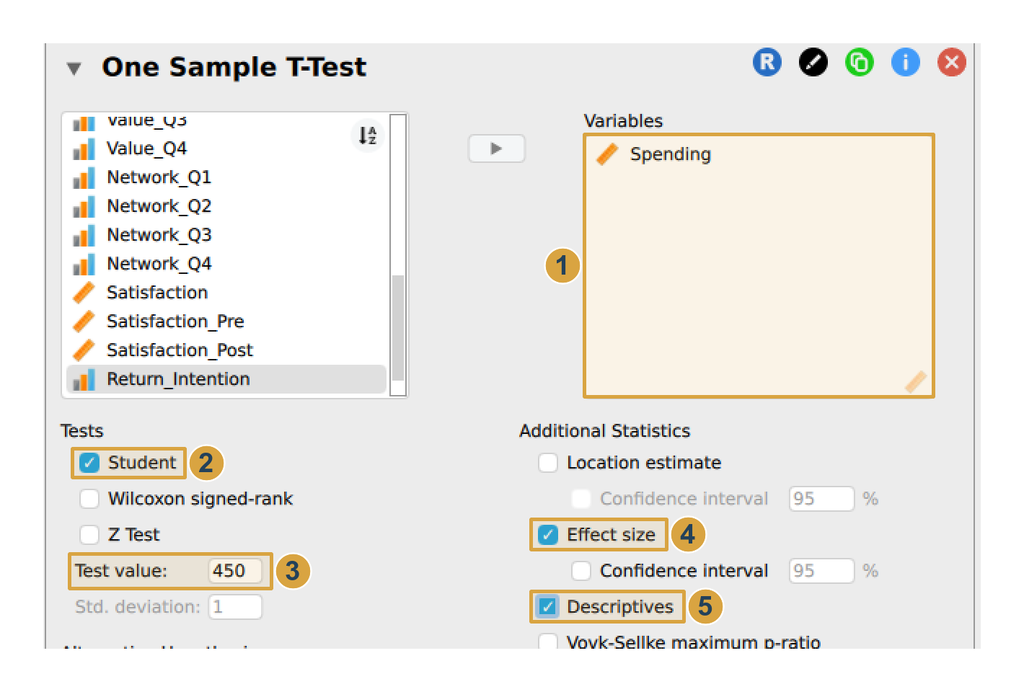

**T-Tests → Classical → One Sample T-Test**

- 1`Spending` into **Variables**
- 2Keep **Student** ticked
- 3**Test value:** 450
- 4Tick **Effect size**
- 5Tick **Descriptives**

## Reading the one-sample output

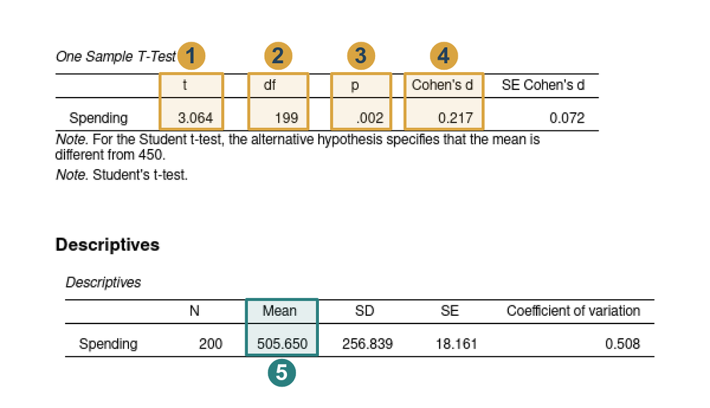

- 1**t = 3.06**
- 2**df = 199:** customers less one
- 3**p = .002:** significant
- 4**d = 0.22:** a small effect
- 5**Mean = 505.65 USD**

## What to report for a one-sample t-test

- the mean and standard deviation
- the benchmark
- **t**, **df** and **p**, and **Cohen’s d**
- a short conclusion in plain language

**Example**

Mean spending (*M* = 505.65, *SD* = 256.84) was higher than the planned 450 USD, *t*(199) = 3.06, *p* = .002, *d* = 0.22. Customers spend more than the plan assumed.

## Your turn: one-sample t-test

Test whether mean `Satisfaction` differs from a target of **4.0**.

- Report *t*, *df*, *p* and *d*
- Write one sentence for the manager

## Break

Ten minutes.

## Wilcoxon signed-rank test

**Main question**

Does one group differ from a benchmark when the outcome is **ordinal**, such as a 1 to 5 rating?

- It compares the **median**, using ranks
- It is the rank-based partner of the one-sample t-test
- **Example:** is the typical intention to return above the midpoint of 3?

## Wilcoxon signed-rank test in JASP

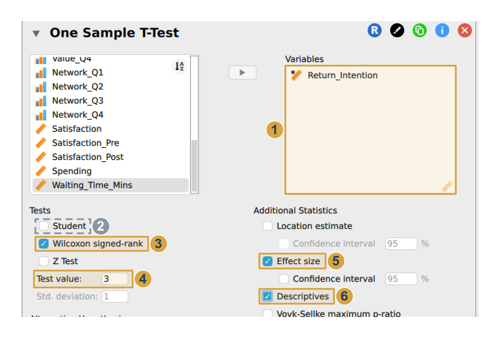

The same panel: **One Sample T-Test**

- 1`Return_Intention` into **Variables**
- 2Untick **Student**
- 3Tick **Wilcoxon signed-rank**
- 4**Test value:** 3
- 5**Effect size** and 6**Descriptives**

## Reading the Wilcoxon output

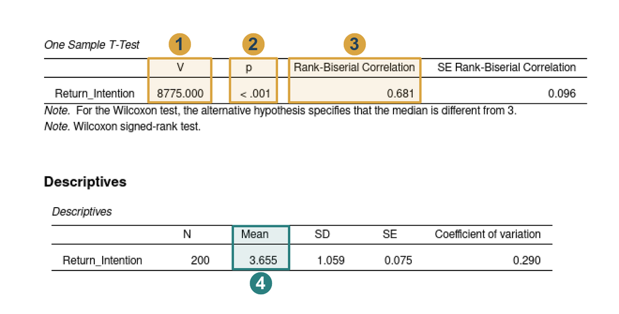

- 1**V = 8775:** the test statistic
- 2**p < .001:** significant
- 3**Rank-biserial r = .68:** large
- 4Mean 3.66; median 4

## What to report for a Wilcoxon signed-rank test

- the **median** and the benchmark
- **V** and **p**, and the rank-biserial correlation
- a short conclusion

**Example**

Return intention (*Mdn* = 4) was higher than the scale midpoint of 3, *V* = 8775, *p* < .001, rank-biserial *r* = .68. Most customers lean towards coming back.

## Your turn: Wilcoxon signed-rank test

Test whether the median rating of `Content_Q1` (1 to 5) differs from **3**.

## Mann-Whitney U test

**Main question**

Do **two independent groups** differ when the outcome is **ordinal** or ranked?

- It compares the two groups through their **ranks**
- It is the right test for ordered outcomes, a full alternative to the t-test
- **Example:** do female and male customers differ in their intention to return?

## Mann-Whitney U test in JASP

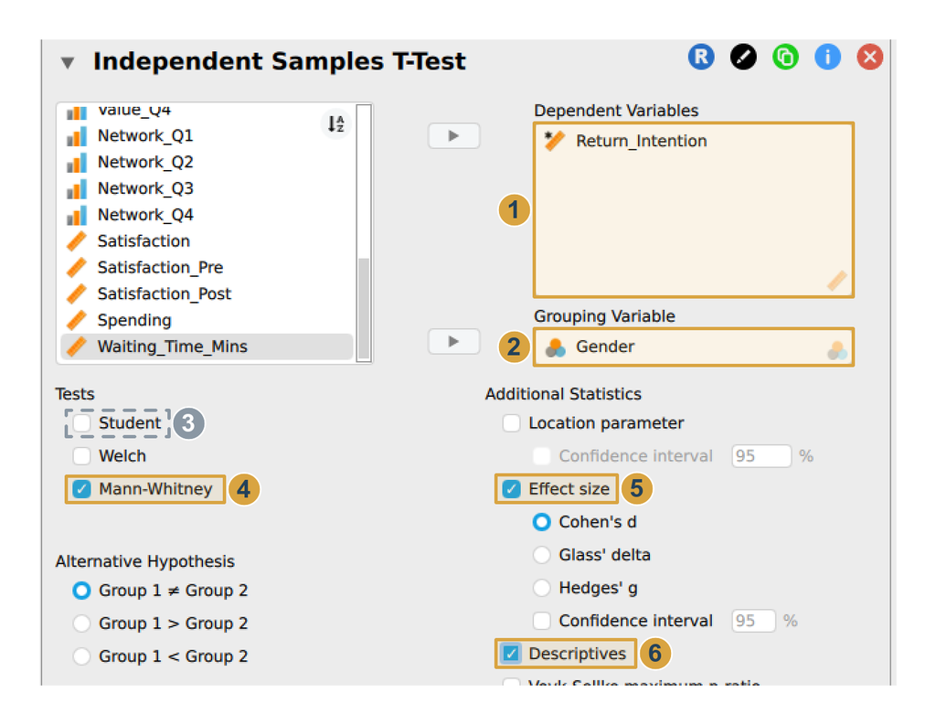

**Independent Samples T-Test**, as in session 1

- 1`Return_Intention` as the outcome
- 2`Gender` as the grouping variable
- 3Untick **Student**
- 4Tick **Mann-Whitney**
- 5**Effect size** and 6**Descriptives**

## Reading the Mann-Whitney output

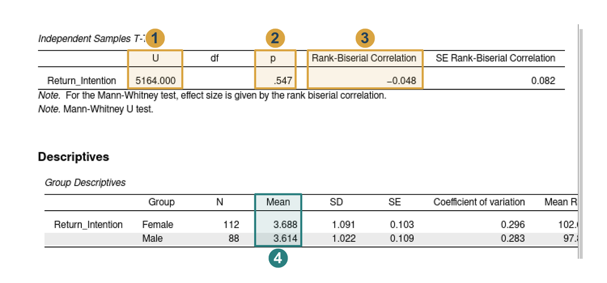

- 1**U = 5164:** the test statistic
- 2**p = .547:** no evidence of a difference
- 3**Rank-biserial r = −.05:** close to zero
- 4Means 3.69 and 3.61; both medians 4

## What to report for a Mann-Whitney U test

- the **U statistic** and the **p-value**
- which group tended to have **higher ranks**, if any
- a short practical conclusion

## Your turn: Mann-Whitney U test

Test whether female and male customers differ in their `Content_Q1` rating (1 to 5).

- Report *U*, *p* and the two medians

## Break

Ten minutes.

## Paired samples t-test

**Main question**

Does the **mean difference** between two measurements of the **same cases** equal zero?

- The analysis works on each person’s **difference**
- Differences between people drop out, so smaller changes can be detected
- **H₀:** the mean change is zero. **H₁:** it is not zero.

## Paired t-test example from the textbook

**Employee training programme**

A company compares employee scores **before training** and **after training** to see whether the programme improved review scores.

- each employee appears **twice**
- the two scores belong to the **same person**
- the test is run on the **differences**

## Paired samples t-test in JASP

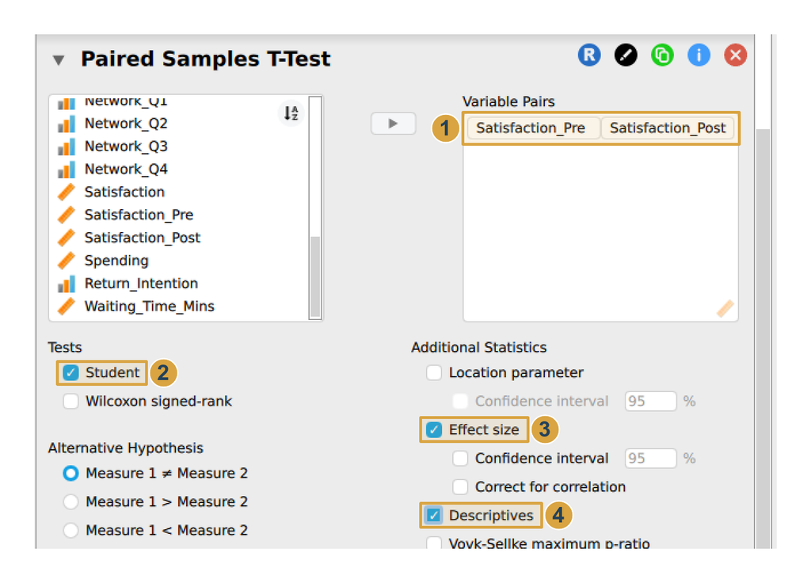

**T-Tests → Classical → Paired Samples T-Test**

- 1Select `Satisfaction_Pre` and `Satisfaction_Post` together, then move them into **Variable Pairs**
- 2Keep **Student** ticked
- 3Tick **Effect size**
- 4Tick **Descriptives**

## Reading the paired output

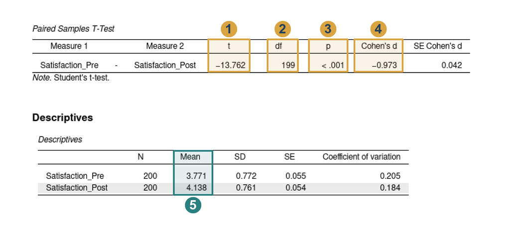

- 1**t = −13.76:** JASP subtracts after from before, so a negative t means a **rise**
- 2**df = 199:** pairs less one
- 3**p < .001:** significant
- 4**d = −0.97:** large
- 53.77 before, 4.14 after

## What to report for a paired t-test

- the mean **before** and the mean **after**
- **t**, **df**, **p** and **Cohen’s d**
- a short conclusion about the change

**Example**

Satisfaction rose from before the event (*M* = 3.77, *SD* = 0.77) to after it (*M* = 4.14, *SD* = 0.76), *t*(199) = −13.76, *p* < .001, *d* = −0.97. Customers are more satisfied after the event than before it.

## Your turn: paired comparison

The same customers rated content (`Content_Q1`) and value (`Value_Q1`), both 1 to 5.

- Which test fits, given that both ratings are **ordinal**?
- Run it on the **Paired Samples T-Test** panel with **Wilcoxon signed-rank** ticked

## Effect size: how big is the difference?

| Effect size | Small | Medium | Large |
| --- | --- | --- | --- |
| Cohen’s d (t-tests) | 0.20 | 0.50 | 0.80 |
| Rank-biserial r (rank tests) | .10 | .30 | .50 |

- A result can be **significant but small**
- A complete interpretation gives **direction**, **size**, **significance** and **practical meaning**

## The tests side by side

| Test | Design | Variable type | Core focus |
| --- | --- | --- | --- |
| One-sample t-test | One group against a benchmark | Scale | Mean against the benchmark |
| Wilcoxon signed-rank | One group against a benchmark | Ordinal | Median against the benchmark |
| Independent samples t-test | Two independent groups | Scale | Difference in means |
| Mann-Whitney U | Two independent groups | Ordinal | Difference in ranks |
| Paired samples t-test | The same cases twice | Scale | Mean of the differences |

## Choosing correctly: four quick scenarios

1. Compare customer waiting time for **Team A** and **Team B**.
   - two different teams, a scale outcome → **independent samples t-test**
2. Compare a five-point service rating across **two unrelated branches**.
   - two different branches, an ordered outcome → **Mann-Whitney U**
3. Compare employee confidence **before and after** training.
   - the same employees twice, a scale outcome → **paired samples t-test**
4. Is the median delivery rating (1 to 5) above the target of **4**?
   - one group against a benchmark, an ordinal outcome → **Wilcoxon signed-rank**

## Common student mistakes

- using an independent t-test for **before-and-after** data
- forgetting that paired analysis works on **differences**
- leaving the **test value** at 0 in a one-sample test
- choosing a t-test for a clearly **ordinal** outcome without a reason
- reporting only the p-value and ignoring the **size and direction** of the difference

## Classroom discussion prompt

A manager says:

> We collected before-and-after scores from the same employees, so I will compare the two means using an independent t-test.
- What is wrong with that choice?
- What should be tested instead?
- Why does the design matter?

## Worked reporting checklist

Before you finish any answer, check that you included:

- the **test name**, and why it fits the **design**
- the correct **statistic**, **df** where there is one, and the **p-value**
- the **effect size**
- the **direction** of the difference
- the **business meaning** of the result

## Recap

**Remember these rules**

- **One group + scale** → **One-sample t-test**; **ordinal** → **Wilcoxon signed-rank**
- **Two groups + scale** → **Independent samples t-test**; **ordinal** → **Mann-Whitney U**
- **Same cases twice + scale** → **Paired samples t-test**; **ordinal** → **paired Wilcoxon**

The design and the variable type decide the test.